# Marrocco_Peak-Quantification

Rebecca Waag

8 6 2023

# Quantification of ATAC data

Perform differential expression analysis, to define which peaks are different between the individual groups. The Marrocco dataset contains 4 groups of animals: 1 - Control 2 - ARS : animals that underwent restraint stress (ARS) and were euthanized 1 week later 3 - FSS : animals that underwent forced swim stress (FSS) for 6 min and were euthanized 40 minutes later 4 - Doublehit: animals that underwent ARS and one week later 6 min FSS. These animals were euthanized 40 minutes after the FSS.

We will focus on identifying those regions that change their accessibility in response to an acute stress session.

```r
suppressPackageStartupMessages({
  library(epiwraps)
  library(motifmatchr)
  library(MotifDb)
  library(universalmotif)
  library(sechm)
  library(BiocParallel)
  library(ggplot2)
  library(chromVAR) # for motif accessibility estimation
  library(SummarizedExperiment) # data structure
  library(edgeR)
  library(stringr) #for word function
  library(rtracklayer)
  library(scales)
})
```

[output not shown]

```
## See system.file("LICENSE", package="MotifDb") for use restrictions.
```

```r
# to control multithreading, unix users can use:
register(MulticoreParam(4))
```

## Perform Differential analysis on peaks

### Import peaks

Prepare a Granges object containing all peaks that appear in one of the samples. Here we are working on all peaks from the ATAC dataset (not just NF-peaks)

```r
#obtain peak names
peaksM <- list.files("/mnt/bohacek/rebecca/training/EpiC/Project/data_Marrocco/peaks/", pattern = "narrowPeak", full = TRUE)
#peaksM

#rename peaks
names(peaksM) <- gsub("\\.narrowPeak","",basename(peaksM))

#import peaks
peaksM <- lapply(peaksM, FUN=rtracklayer::import)
length(peaksM) #24 peak files
```

```
## [1] 24
```

### Getting a consensus set of windows

A consensus set of peaks, containing all peaks that appear in at least one of the samples is produced. Blacklisted regions, those that generally have high signals independent of the experiment, are removed. Of the remaining peaks, only those that appear in at least three samples are kept.

```r
#create consensus peaks
merged_peaksM <- reduce(unlist(GRangesList(peaksM)), with.revmap=TRUE)
#length(merged_peaksM) #196887

#remove blacklisted regions from consensus peaks
blacklist <- import("/reference/Mus_musculus/GRCm38.blacklist.bed")
merged_peaksM <- merged_peaksM[!overlapsAny(merged_peaksM, blacklist)]
#length(merged_peaksM) #196815

#only keep peaks that appear in at least 3 samples
merged_peaksM <- merged_peaksM[lengths(merged_peaksM$revmap)>=3]
#length(merged_peaksM) #99852
```

### Getting the counts per peak

Prepare a matrix of fragment counts in the merged peaks as a summarized experiment object for DEA.

```r
#list bam files
bams <- list.files("/mnt/bohacek/Marrocco_GSE200670_stressATAC/aligned/", pattern="bam$", full=TRUE)

#create summarized experiment object
#se <- chromVAR::getCounts(alignment_files=bams,
#                             peaks=merged_peaksM,
#                             paired =  TRUE,
#                             format = "bam")
se <- readRDS("/mnt/bohacek/rebecca/training/EpiC/Project/Marroccopeaks.SE.rds")

#explore assay
se
```

```
## class: RangedSummarizedExperiment
## dim: 99852 24
## metadata(1): anno_colors
## assays(2): counts corrected
## rownames(99852): 1:3113274-3113871 1:3119599-3120560 ...
##   Y:90838332-90840404 GL456354.1:171609-172880
## rowData names(1): revmap
## colnames(24): ARS_female_GSM6041847 ARS_female_GSM6041848 ...
##   FSS_male_GSM6041857 FSS_male_GSM6041858
## colData names(7): depth group ... stress SV1
```

```r
assays(se) #contains counts
```

```
## List of length 2
## names(2): counts corrected
```

```r
#plot sequencing depth
#barplot(se$depth)
#sequencing depth of all samples is pretty different

#adjust the colnames
#colnames(se)
colnames(se) <- gsub("\\.bam","",basename(bams))

#extract group from filename and add as metadata
se$group <- word(colnames(se), 1, sep = "_")
se$group <- as.factor(se$group)
#se$group
#levels(se$group)
se$group<-relevel(se$group, "Control")
levels(se$group)
```

```
## [1] "Control"    "ARS"        "Double-hit" "FSS"
```

```r
#extract sex from filename and add as metadata
se$sex<-word(colnames(se), 2, sep = "_")
se$sex <- as.factor(se$sex)
#se$sex
#levels(se$sex)
se$sex<-relevel(se$sex, "male")
levels(se$sex)
```

```
## [1] "male"   "female"
```

```r
#extract ID from filename and add as metadata
se$id<-word(colnames(se), 3, sep = "_")
se$id <- as.factor(se$id)
se$id
```

```
##  [1] GSM6041847 GSM6041848 GSM6041849 GSM6041850 GSM6041851 GSM6041852
##  [7] GSM6041841 GSM6041842 GSM6041843 GSM6041844 GSM6041845 GSM6041846
## [13] GSM6041859 GSM6041860 GSM6041861 GSM6041862 GSM6041863 GSM6041864
## [19] GSM6041853 GSM6041854 GSM6041855 GSM6041856 GSM6041857 GSM6041858
## 24 Levels: GSM6041841 GSM6041842 GSM6041843 GSM6041844 ... GSM6041864
```

```r
#by default there are no rownames, us regions as row.names
row.names(se) <- as.character(granges(se))
```

### Data Exploration

Explore data and visualize differences in the region counts using PCA.

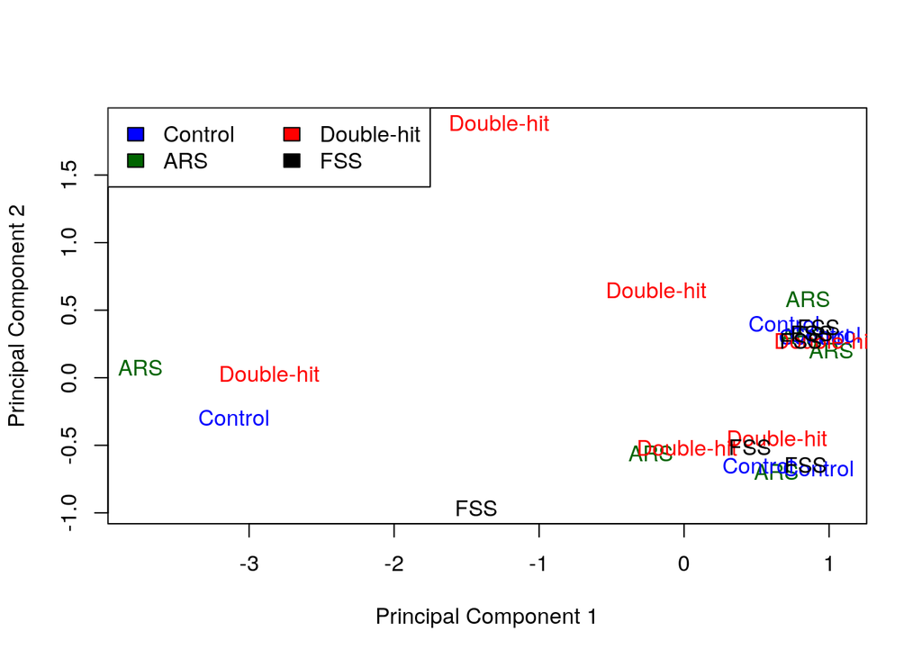

FIGURE 1: PCA of peak counts for original groups

```r
#plot PCA of experiment visualizing
colors <- c("blue", "darkgreen", "red", "black")
plotMDS(se, col=colors[se$group], labels=se$group, gene.selection="common")
legend("topleft", fill=colors, legend=levels(se$group), col=colors, ncol=2)
```

The groups do not nicely separate along PC1 or PC2 (Fig. 1), therefore, a surrogate variable is added to the analysis as a covariate.

### Differential analysis with edgeR

```r
#prepare DGE object
y <- DGEList(counts=assays(se)$counts)

#calculate normalization, assumptions are met in this experiment, so we can use TMM normalization
y <- calcNormFactors(y)

#filter by expression
#y <- y[filterByExpr(y,group=se$group),]

#calculate covariate
se <- SEtools::svacor(se, ~ sex + group, n.sv=1)
```

```
## Using variance-stabilizing transformation
```

```
##   Note: levels of factors in the design contain characters other than
##   letters, numbers, '_' and '.'. It is recommended (but not required) to use
##   only letters, numbers, and delimiters '_' or '.', as these are safe characters
##   for column names in R. [This is a message, not a warning or an error]
##   Note: levels of factors in the design contain characters other than
##   letters, numbers, '_' and '.'. It is recommended (but not required) to use
##   only letters, numbers, and delimiters '_' or '.', as these are safe characters
##   for column names in R. [This is a message, not a warning or an error]
```

```
## Number of significant surrogate variables is:  1
## Iteration (out of 5 ):1  2  3  4  5
```

```r
assays(se) #corrected assay added
```

```
## List of length 2
## names(2): counts corrected
```

```r
#specify model matrix to compare between the different groups, correcting for sex and SV1
mm <- model.matrix(~ sex + SV1 + group, data=as.data.frame(colData(se)))
#we use an intercept here, meaning that we compare against the controls set above

#estimate dispersion
y <- estimateDisp(y,mm)
y$common.dispersion
```

```
## [1] 0.1928259
```

```r
#plot dispersion estimates
#plotBCV(y)

#fit model
fit <- glmQLFit(y, mm)

#check coefficients
colnames(mm)
```

```
## [1] "(Intercept)"     "sexfemale"       "SV1"             "groupARS"
## [5] "groupDouble-hit" "groupFSS"
```

```r
#[1] "(Intercept)"     "sexfemale"       "SV1"             "groupARS"        "groupDouble-hit" "groupFSS"

#create list for results
results_M <- list()

#compare ARS vs. control
results_M[["Marrocco.ARS"]] <- glmQLFTest(fit, coef="groupARS")
topTags(results_M[["Marrocco.ARS"]])
```

```
## Coefficient:  groupARS
##                           logFC    logCPM        F       PValue       FDR
## 4:93482724-93483014    8.616187 2.4661337 25.95519 1.437482e-05 0.9999611
## 1:168779551-168779877  7.796306 4.3465567 17.60329 1.958271e-04 0.9999611
## 12:102515306-102515954 4.030044 0.4127627 14.60279 5.644208e-04 0.9999611
## 7:34869445-34870164    1.481053 0.8988325 14.14763 6.672283e-04 0.9999611
## 9:121929352-121932017  3.099235 1.0046749 13.91294 7.278963e-04 0.9999611
## 8:20394852-20395829    1.866366 1.6477765 13.90780 7.292894e-04 0.9999611
## 1:80630055-80631015    1.498093 1.0537257 12.28098 1.352984e-03 0.9999611
## 7:79332313-79333166    1.764615 0.1890375 12.21185 1.389808e-03 0.9999611
## 8:77187201-77188613    1.929969 1.3446662 11.83754 1.608734e-03 0.9999611
## 17:8457011-8457856     2.121459 0.5300582 11.73140 1.677329e-03 0.9999611
```

```r
summary(decideTests(results_M[["Marrocco.ARS"]]))
```

```
##        groupARS
## Down          0
## NotSig    99852
## Up            0
```

```r
#       groupARS
#Down          0
#NotSig    99852
#Up            0

#compare FSS vs. control
results_M[["Marrocco.FSS"]] <- glmQLFTest(fit, coef="groupFSS")
topTags(results_M[["Marrocco.FSS"]])
```

```
## Coefficient:  groupFSS
##                           logFC   logCPM        F       PValue          FDR
## 4:149889375-149890818 1.3692786 4.235526 66.67956 2.174436e-09 0.0002171217
## 9:48735911-48738043   1.3059401 5.229919 58.49638 9.025343e-09 0.0002590354
## 17:28517437-28518714  1.0773930 5.178828 57.91444 1.003599e-08 0.0002590354
## 17:56108434-56110267  1.2422903 5.094010 57.73215 1.037677e-08 0.0002590354
## 7:63896350-63897837   0.9588446 5.334238 43.58195 1.755697e-07 0.0035061969
## 7:142001031-142002594 1.3606908 3.435857 40.39917 3.574199e-07 0.0059481816
## 7:113457945-113458678 2.4613821 1.391351 38.81606 5.152074e-07 0.0073492123
## 17:28522429-28523992  1.0069100 5.439992 36.50937 8.913477e-07 0.0104812608
## 8:64880426-64881715   1.5582899 2.916477 36.26929 9.447116e-07 0.0104812608
## 4:56654223-56655718   1.6650934 3.273580 35.12369 1.250481e-06 0.0124863069
```

```r
summary(decideTests(results_M[["Marrocco.FSS"]]))
```

```
##        groupFSS
## Down          0
## NotSig    99818
## Up           34
```

```r
#       groupFSS
#Down          0
#NotSig    99818
#Up           34

#compare Doublehit vs. control
results_M[["Marrocco.Doublehit"]] <- glmQLFTest(fit, coef="groupDouble-hit")
topTags(results_M[["Marrocco.Doublehit"]])
```

```
## Coefficient:  groupDouble-hit
##                            logFC   logCPM        F       PValue          FDR
## 4:149889375-149890818  1.3396762 4.235526 62.46636 4.454561e-09 0.0004447968
## 7:142001031-142002594  1.5643676 3.435857 51.28609 3.541072e-08 0.0017679156
## 9:48735911-48738043    1.1930812 5.229919 48.09459 6.742949e-08 0.0018938540
## 3:101011978-101013156  1.8259346 3.338176 47.52408 7.586644e-08 0.0018938540
## 17:56108434-56110267   1.1065335 5.094010 44.83389 1.338609e-07 0.0026475035
## 11:101699909-101701419 1.5167642 3.848952 43.42367 1.817541e-07 0.0026475035
## 17:28517437-28518714   0.9428291 5.178828 43.32810 1.855999e-07 0.0026475035
## 7:63896350-63897837    0.9574393 5.334238 42.11725 2.425669e-07 0.0030275993
## 19:29023705-29025378   1.4012550 4.176524 39.26233 4.643536e-07 0.0046195051
## 8:121561755-121563642  1.2365402 3.890287 39.12810 4.790639e-07 0.0046195051
```

```r
summary(decideTests(results_M[["Marrocco.Doublehit"]]))
```

```
##        groupDouble-hit
## Down                 0
## NotSig           99817
## Up                  35
```

```r
#      groupDouble-hit
#Down                 0
#NotSig           99817
#Up                  35

#calculate fdr
for(i in names(results_M)){
  results_M[[i]]$table$FDR <- p.adjust(results_M[[i]]$table$PValue, method = "fdr")
}

#calculate which regions are overlapping between FSS and Double-hit hits
length(Reduce(intersect, list(which(results_M$Marrocco.FSS$table$FDR<0.05),which(results_M$Marrocco.Doublehit$table$FDR<0.05)))) #24
```

```
## [1] 24
```

The DA reveals 34 signficantly accessible regions between FSS and control. Between double-hit and control, there are 35 significantly accessible regions. ARS seems to do not elicit any differential accessible regions 1 week later, indicating that (restraint) stress has no long-lasting effect on chromatin accessibility.

Of the differentially accessible regions of FSS and Double-hit, 24 are consistent between those two conditions, indicating a strong influence of the current stress exposure both groups of animals were exposed to. Therefore, new factors will be introduced to take into account the acute stress exposure, as well as the history of stress some animals underwent. The new factors are acute stress (FSS, Double-hit) and a history of stress (ARS, double-hit).

```r
#add new metadata based on the groups
se$group
```

```
##  [1] ARS        ARS        ARS        ARS        ARS        ARS
##  [7] Control    Control    Control    Control    Control    Control
## [13] Double-hit Double-hit Double-hit Double-hit Double-hit Double-hit
## [19] FSS        FSS        FSS        FSS        FSS        FSS
## Levels: Control ARS Double-hit FSS
```

```r
#add history of stress factor (ARS)
se$history <- c(rep("history", 6), rep("no", 6), rep("history", 6), rep("no",6))
se$history <- as.factor(se$history)
se$history<-relevel(se$history, "no")
se$history
```

```
##  [1] history history history history history history no      no      no
## [10] no      no      no      history history history history history history
## [19] no      no      no      no      no      no
## Levels: no history
```

```r
#add acute stress factor (FSS)
se$stress <- c(rep("no", 12), rep("acute", 12))
se$stress <- as.factor(se$stress)
se$stress<-relevel(se$stress, "no")
se$stress
```

```
##  [1] no    no    no    no    no    no    no    no    no    no    no    no
## [13] acute acute acute acute acute acute acute acute acute acute acute acute
## Levels: no acute
```

```r
#prepare DGE object
y <- DGEList(counts=assays(se)$counts)

#calculate normalization, assumptions are met in this experiment, so we can use TMM normalization
y <- calcNormFactors(y)

#filter by expression
#y <- y[filterByExpr(y,group=se$group),]

#calculate covariate
se <- SEtools::svacor(se, ~ sex + history + stress, n.sv=1)
```

```
## Using variance-stabilizing transformation
```

```
## Number of significant surrogate variables is:  1
## Iteration (out of 5 ):1  2  3  4  5
```

```r
assays(se) #corrected assay added
```

```
## List of length 2
## names(2): counts corrected
```

```r
#specify model matrix to compare between the stress and control, correcting for history of stress, sex and SV1
mm <- model.matrix(~ sex + SV1 + history + stress, data=as.data.frame(colData(se)))
#we use an intercept here, meaning that we compare against the controls that were set before

#estimate dispersion
y <- estimateDisp(y,mm)

#fit model
fit <- glmQLFit(y, mm)

#check coefficients
colnames(mm)
```

```
## [1] "(Intercept)"    "sexfemale"      "SV1"            "historyhistory"
## [5] "stressacute"
```

```r
#[1] "(Intercept)"    "sexfemale"      "SV1"            "historyhistory" "stressacute"

#get results
#results_M <- list()

#compare history vs. control
results_M[["Marrocco.history"]] <- glmQLFTest(fit, coef="historyhistory")
topTags(results_M[["Marrocco.history"]])
```

```
## Coefficient:  historyhistory
##                          logFC     logCPM        F       PValue FDR
## 1:168779551-168779877 5.985597  4.3460302 22.08085 0.0000435049   1
## 13:91084555-91085716  2.200513 -1.0112939 18.28889 0.0001494564   1
## 4:93482724-93483014   4.800508  2.4642612 16.10563 0.0003187060   1
## 13:85126725-85127387  1.318589  7.5752194 15.48985 0.0003973191   1
## 9:124256347-124257987 1.003901  3.7639062 15.11665 0.0004548272   1
## 6:9889948-9890155     1.239678  8.8978541 15.05743 0.0004647397   1
## 8:20812410-20813095   1.426385  0.3716545 15.05584 0.0004650091   1
## 2:22588670-22590197   1.201056 12.1013592 14.56862 0.0005559170   1
## MT:5371-6605          1.152397 14.7966838 14.43134 0.0005848253   1
## MT:12121-16138        1.156748 16.4114542 14.35272 0.0006020990   1
```

```r
summary(decideTests(results_M[["Marrocco.history"]]))
```

```
##        historyhistory
## Down                0
## NotSig          99852
## Up                  0
```

```r
#       groupARS
#Down          0
#NotSig    99852
#Up            0

#compare acute stress vs. control
results_M[["Marrocco.acute"]] <- glmQLFTest(fit, coef="stressacute")
topTags(results_M[["Marrocco.acute"]])
```

```
## Coefficient:  stressacute
##                            logFC   logCPM         F       PValue          FDR
## 4:149889375-149890818  1.3768100 4.235539 144.06440 1.149014e-13 1.147313e-08
## 17:56108434-56110267   1.1174866 5.094015  95.47702 2.515062e-11 1.255670e-06
## 7:142001031-142002594  1.4058974 3.435864  91.14166 4.480691e-11 1.491353e-06
## 7:63896350-63897837    0.9240823 5.334238  85.27447 1.012102e-10 2.473407e-06
## 7:113457945-113458678  2.4671816 1.391380  82.41173 1.528920e-10 2.473407e-06
## 3:101011978-101013156  1.6907235 3.338190  82.00588 1.622362e-10 2.473407e-06
## 4:56654223-56655718    1.7259122 3.273617  81.00278 1.880266e-10 2.473407e-06
## 8:64880426-64881715    1.5917510 2.916505  80.64782 1.981658e-10 2.473407e-06
## 9:48735911-48738043    1.0902736 5.229920  78.53692 2.717572e-10 3.015055e-06
## 11:101699909-101701419 1.3527852 3.848971  75.97404 4.020458e-10 4.014508e-06
```

```r
summary(decideTests(results_M[["Marrocco.acute"]]))
```

```
##        stressacute
## Down             1
## NotSig       99518
## Up             333
```

```r
#       stressacute
#Down          1
#NotSig    99518
#Up          333

#calculate fdr
for(i in names(results_M)){
  results_M[[i]]$table$FDR <- p.adjust(results_M[[i]]$table$PValue, method = "fdr")
}
```

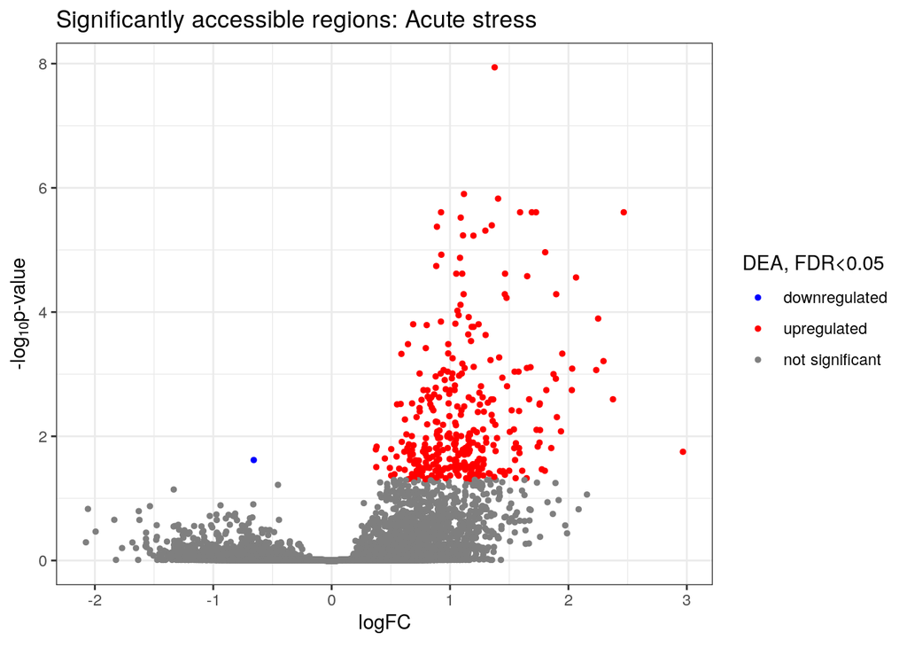

FIGURE 2: Volcanoplot showing significantly accessible regions between control and acutely-stressed animals

```r
#look at data using volcano plot to show regions with increased or decreased baccessibility of acute stress
#classify sign. up and downregulated peaks
results_M$Marrocco.acute$table$diff[results_M$Marrocco.acute$table$FDR < 0.05 & results_M$Marrocco.acute$table$logFC >0] <- "UP"
results_M$Marrocco.acute$table$diff[results_M$Marrocco.acute$table$FDR < 0.05 & results_M$Marrocco.acute$table$logFC <0] <- "DOWN"

#visualize results
ggplot(results_M$Marrocco.acute$table, aes(logFC, -log10(FDR), col=results_M$Marrocco.acute$table$diff)) + geom_point(size=1) + theme_bw() + scale_color_manual(values = c("blue", "red"), labels =c ("downregulated", "upregulated", "not significant")) + ggtitle('Significantly accessible regions: Acute stress') + labs(color = 'DEA, FDR<0.05', x = expression("logFC"), y = expression("-log"[10]*"p-value"))
```

Visualizing the regions in a volcano plot shows that all but one regions are significantly more open upon stress, meaning they show increased accessibility (Fig. 2).

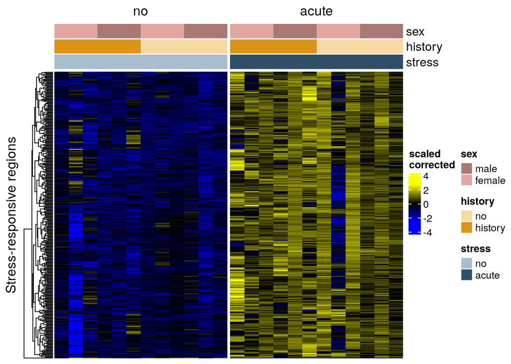

FIGURE 3: Heatmap showing differentially-accessible regions between control and acutely-stressed animals (corrected)

```r
#add metadata column to SE object to define colors
metadata(se)$anno_colors$stress <- c(no="#A8BED0", acute="#2F4E67")
metadata(se)$anno_colors$history <- c(no="#F7D9A3", history="#DB9413")
metadata(se)$anno_colors$sex <- c(male="#A87974", female="#E4A6A0")

#visualize uncorrected counts in heatmap
#sechm(se,features = rownames(topTags(results_M$Marrocco.acute, n = Inf, p.value = 0.05)), do.scale=TRUE, #assayName="counts", row_title="Stress-responsive regions", gaps_at = "stress", cluster_rows = TRUE, #top_annotation=c("sex", "history", "stress"))

#visualize corrected counts in heatmap
sechm(se,features = rownames(topTags(results_M$Marrocco.acute, n = Inf, p.value = 0.05)), do.scale=TRUE, assayName="corrected", row_title="Stress-responsive regions", gaps_at = "stress", cluster_rows = TRUE, top_annotation=c("sex", "history", "stress"))
```

```r
#save summarized experiments object
saveRDS(se, file="Marroccopeaks.SE.rds")
```

334 regions are differentially accessible between acutely stressed (FSS, double-hit) and non-acutely stressed (Control, ARS) animals, correcting for the different history of stress, sex and covariate (Fig. 3). Most of these (333) are upregulated in response to acute stress. No differentially accessible regions are found when testing for the effect of a history of stress.

```r
#subset all significant stress peaks from Marrocco data set
#dim(results_M[["Marrocco.acute"]]$table) #99852
#length(merged_peaksM) #99852
peaksM_stress_sig <- merged_peaksM[which(results_M[["Marrocco.acute"]]$table$FDR<0.05)]
#length(peaksM_stress_sig) #334 peaks

#subset sign. upregulated peaks
peaksM_stress_sigup <- merged_peaksM[which((results_M[["Marrocco.acute"]]$table$FDR<0.05) & (results_M[["Marrocco.acute"]]$table$logFC>0))]
#length(peaksM_stress_sigup) #333

#save peaks
saveRDS(peaksM_stress_sig, file="peaksM_stress_sig.rds")
saveRDS(peaksM_stress_sigup, file="peaksM_stress_sigup.rds")
```

### Enrichment analysis of stress-upregulated peaks

Enrichment analysis on the peaks was performed using the rGREAT server. As background, all accessible peaks (merged peaks file that was previously used to construct the SE object) from the Marrocco dataset will be used.

```r
#perform enrichment analysis using rGREAT server
library(rGREAT)
#adjust seqlevelStyle for rGREAT server
seqlevelsStyle(merged_peaksM) <- "UCSC"
seqlevelsStyle(peaksM_stress_sig) <- "UCSC"
seqlevelsStyle(peaksM_stress_sigup) <- "UCSC"

#only keep common chromosome names and clean up Granges for rGREAT
seqnames(merged_peaksM)
```

```
## factor-Rle of length 99852 with 47 runs
##   Lengths:       6818       4888       6773 ...         43          1
##   Values : chr1       chr10      chr11      ... chrY       GL456354.1
## Levels(57): chr1 chr10 chr11 chr12 ... JH584296.1 GL456366.1 GL456382.1
```

```r
chrom <- c("chr1", "chr10", "chr11", "chr12", "chr13", "chr14", "chr15", "chr16", "chr17", "chr18", "chr19", "chr2", "chr3", "chr4", "chr5", "chr6", "chr7", "chr8", "chr9", "chrM", "chrX", "chrY")
merged_peaksM_chrom<- keepSeqlevels(merged_peaksM, value=chrom, pruning.mode="coarse")
length(merged_peaksM_chrom) #99764
```

```
## [1] 99764
```

```r
names(merged_peaksM_chrom) <-NULL
seqnames(peaksM_stress_sig)
```

```
## factor-Rle of length 334 with 20 runs
##   Lengths:    27    15    16    14    21 ...    18    31    17    20     5
##   Values : chr1  chr10 chr11 chr12 chr13 ... chr6  chr7  chr8  chr9  chrX
## Levels(57): chr1 chr10 chr11 chr12 ... JH584296.1 GL456366.1 GL456382.1
```

```r
peaksM_stress_sig_chrom<- keepSeqlevels(peaksM_stress_sig, value=chrom, pruning.mode="coarse")
length(peaksM_stress_sig_chrom) #334
```

```
## [1] 334
```

```r
names(peaksM_stress_sig_chrom) <-NULL
peaksM_stress_sigup_chrom<- keepSeqlevels(peaksM_stress_sigup, value=chrom, pruning.mode="coarse")
length(peaksM_stress_sigup_chrom) #333
```

```
## [1] 333
```

```r
names(peaksM_stress_sigup_chrom) <-NULL

#get enrichment results for all sign peaks
#job_stress_sig <- rGREAT::submitGreatJob(gr=peaksM_stress_sig_chrom, bg=merged_peaksM_chrom, species="mm10") #we use mm10, cause GRCm38 is not supported
#res_stress_sig <- rGREAT::getEnrichmentTables(job_stress_sig)
#res_stress_sig

#plot the top 30 Biological processes
#bp_stress_sig <- res_stress_sig$`GO Biological Process`
#bp_stress_sig
#sum(bp_stress_sig$Hyper_Adjp_BH<0.05) #54 GO terms are sign. enriched
#ggplot(head(bp_stress_sig,30), aes(Hyper_Fold_Enrichment, reorder(name, Hyper_Adjp_BH), size=Hyper_Foreground_Region_Hits, color=-log10(Hyper_Adjp_BH))) + geom_point() + scale_color_viridis_c() + ggtitle("Stress-responsive peaks: Biological Processes") + scale_y_discrete(labels = label_wrap(50))

#get enrichment results for all sign upregulated peaks
job_stress_sigup <- rGREAT::submitGreatJob(gr=peaksM_stress_sigup_chrom, bg=merged_peaksM_chrom, species="mm10") #we use mm10, cause GRCm38 is not supported
res_stress_sigup <- rGREAT::getEnrichmentTables(job_stress_sigup)
```

```
## The default enrichment tables contain no associated genes for the input
## regions. You can set `download_by = 'tsv'` to download the complete
## table, but note only the top 500 regions can be retreived. See the
## following link:
##
## https://great-help.atlassian.net/wiki/spaces/GREAT/pages/655401/Export#Export-GlobalExport
```

```r
#res_stress_sig

#plot the top 30 Biological processes
bp_stress_sigup <- res_stress_sigup$`GO Biological Process`
#bp_stress_sig
sum(bp_stress_sigup$Hyper_Adjp_BH<0.05) #52 GO terms are sign. enriched
```

```
## [1] 52
```

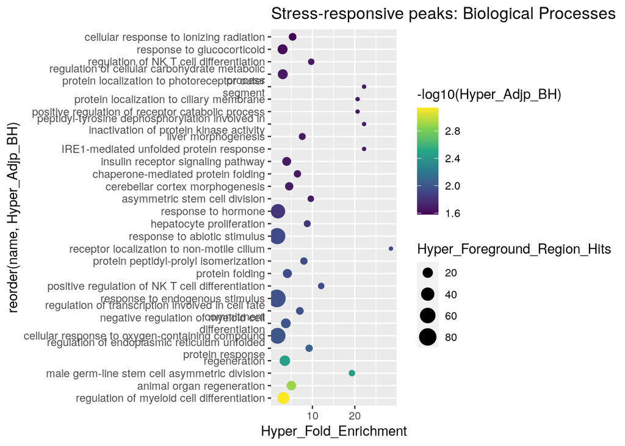

FIGURE 4: Enrichment analysis of significantly more accessible regions

```r
ggplot(head(bp_stress_sigup,30), aes(Hyper_Fold_Enrichment, reorder(name, Hyper_Adjp_BH), size=Hyper_Foreground_Region_Hits, color=-log10(Hyper_Adjp_BH))) + geom_point() + scale_color_viridis_c() + ggtitle("Stress-responsive peaks: Biological Processes") + scale_y_discrete(labels = label_wrap(50))
```

## Perform Differential analysis on NF-peaks

So far, analysis was performed on ALL accessible regions of the genome, in a next step, the same analysis will be performed using only the peaks (==NF-peaks) called on the nucleosome-free (NF) bams. These regions should be especially relevant for TF-guided action.

## Import NF peaks only

```r
#obtain peak names
peaksM_NF <- list.files("/mnt/bohacek/rebecca/training/EpiC/Project/data_Marrocco/NF-peaks/", pattern = "narrowPeak", full = TRUE)
#peaksM_NF

#rename peaks
names(peaksM_NF) <- gsub("\\.narrowPeak","",basename(peaksM_NF))

#import peaks
peaksM_NF <- lapply(peaksM_NF, FUN=rtracklayer::import)
#length(peaksM_NF) #25 peak files

#get rid of merged peaks
peaksM_NF <- peaksM_NF[1:24]
#length(peaksM_NF) #24 files
```

### Getting a consensus set of windows

```r
#create consensus peaks
merged_peaksM_NF <- reduce(unlist(GRangesList(peaksM_NF)), with.revmap=TRUE)
length(merged_peaksM_NF) #557480
```

```
## [1] 557480
```

```r
#remove blacklisted regions from consensus peaks
blacklist <- import("/reference/Mus_musculus/GRCm38.blacklist.bed")
merged_peaksM_NF <- merged_peaksM_NF[!overlapsAny(merged_peaksM_NF, blacklist)]
length(merged_peaksM_NF) #557470
```

```
## [1] 557470
```

```r
#only keep peaks that appear in at least 3 samples
merged_peaksM_NF <- merged_peaksM_NF[lengths(merged_peaksM_NF$revmap)>=3]
length(merged_peaksM_NF) #141235
```

```
## [1] 141235
```

```r
#several of these peaks are very specific to samples and are not present across several of these
```

### Getting the counts per peak

We prepare another se object that contains the NF-peaks.

```r
#list bam files
bams_NF <- list.files("/mnt/bohacek/Marrocco_GSE200670_stressATAC/NFbam/", pattern="bam$", full=TRUE)
bams_NF <- bams_NF[1:24]
bams_NF
```

```
##  [1] "/mnt/bohacek/Marrocco_GSE200670_stressATAC/NFbam//ARS_female_GSM6041847.shifted.bam"
##  [2] "/mnt/bohacek/Marrocco_GSE200670_stressATAC/NFbam//ARS_female_GSM6041848.shifted.bam"
##  [3] "/mnt/bohacek/Marrocco_GSE200670_stressATAC/NFbam//ARS_female_GSM6041849.shifted.bam"
##  [4] "/mnt/bohacek/Marrocco_GSE200670_stressATAC/NFbam//ARS_male_GSM6041850.shifted.bam"
##  [5] "/mnt/bohacek/Marrocco_GSE200670_stressATAC/NFbam//ARS_male_GSM6041851.shifted.bam"
##  [6] "/mnt/bohacek/Marrocco_GSE200670_stressATAC/NFbam//ARS_male_GSM6041852.shifted.bam"
##  [7] "/mnt/bohacek/Marrocco_GSE200670_stressATAC/NFbam//Control_female_GSM6041841.shifted.bam"
##  [8] "/mnt/bohacek/Marrocco_GSE200670_stressATAC/NFbam//Control_female_GSM6041842.shifted.bam"
##  [9] "/mnt/bohacek/Marrocco_GSE200670_stressATAC/NFbam//Control_female_GSM6041843.shifted.bam"
## [10] "/mnt/bohacek/Marrocco_GSE200670_stressATAC/NFbam//Control_male_GSM6041844.shifted.bam"
## [11] "/mnt/bohacek/Marrocco_GSE200670_stressATAC/NFbam//Control_male_GSM6041845.shifted.bam"
## [12] "/mnt/bohacek/Marrocco_GSE200670_stressATAC/NFbam//Control_male_GSM6041846.shifted.bam"
## [13] "/mnt/bohacek/Marrocco_GSE200670_stressATAC/NFbam//Double-hit_female_GSM6041859.shifted.bam"
## [14] "/mnt/bohacek/Marrocco_GSE200670_stressATAC/NFbam//Double-hit_female_GSM6041860.shifted.bam"
## [15] "/mnt/bohacek/Marrocco_GSE200670_stressATAC/NFbam//Double-hit_female_GSM6041861.shifted.bam"
## [16] "/mnt/bohacek/Marrocco_GSE200670_stressATAC/NFbam//Double-hit_male_GSM6041862.shifted.bam"
## [17] "/mnt/bohacek/Marrocco_GSE200670_stressATAC/NFbam//Double-hit_male_GSM6041863.shifted.bam"
## [18] "/mnt/bohacek/Marrocco_GSE200670_stressATAC/NFbam//Double-hit_male_GSM6041864.shifted.bam"
## [19] "/mnt/bohacek/Marrocco_GSE200670_stressATAC/NFbam//FSS_female_GSM6041853.shifted.bam"
## [20] "/mnt/bohacek/Marrocco_GSE200670_stressATAC/NFbam//FSS_female_GSM6041854.shifted.bam"
## [21] "/mnt/bohacek/Marrocco_GSE200670_stressATAC/NFbam//FSS_female_GSM6041855.shifted.bam"
## [22] "/mnt/bohacek/Marrocco_GSE200670_stressATAC/NFbam//FSS_male_GSM6041856.shifted.bam"
## [23] "/mnt/bohacek/Marrocco_GSE200670_stressATAC/NFbam//FSS_male_GSM6041857.shifted.bam"
## [24] "/mnt/bohacek/Marrocco_GSE200670_stressATAC/NFbam//FSS_male_GSM6041858.shifted.bam"
```

```r
#create summarized experiment object
#se_NF <- chromVAR::getCounts(alignment_files=bams_NF,
#                             peaks=merged_peaksM_NF,
#                             paired =  TRUE,
#                             format = "bam")

se_NF <- readRDS("/mnt/bohacek/rebecca/training/EpiC/Project/MarroccopeaksNF.SE.rds")


#se_NF
#assay(se_NF)

#plot sequencing depth
#barplot(se_NF$depth)

#adjust the colnames
#colnames(se)
colnames(se_NF) <- gsub("\\.bam","",basename(bams_NF))

#extract group from filename and add as metadata
se_NF$group <- word(colnames(se_NF), 1, sep = "_")
se_NF$group <- as.factor(se_NF$group)
#se_NF$group
#levels(se_NF$group)
se_NF$group<-relevel(se_NF$group, "Control")

#extract sex from filename and add as metadata
se_NF$sex<-word(colnames(se_NF), 2, sep = "_")
se_NF$sex <- as.factor(se_NF$sex)
#se_NF$sex
#levels(se_NF$sex)
se_NF$sex<-relevel(se_NF$sex, "male")

#extract ID from filename and add as metadata
se_NF$id<-word(colnames(se_NF), 3, sep = "_")
se_NF$id <- as.factor(se_NF$id)
#se_NF$id

#give names to regions, by default there are no rownames, use row.names
row.names(se_NF) <- as.character(granges(se_NF))
```

## Data Exploration

Explore data and visualize the difference in the expression profiles using PCA.

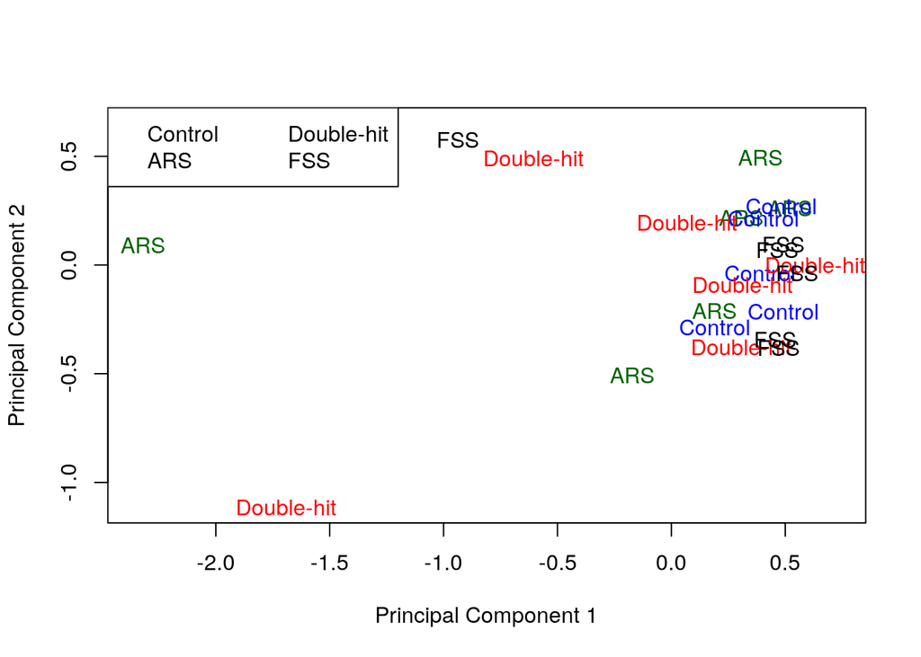

FIGURE 5: PCA of peak counts for original groups

```r
#plot PCA of animals
colors <- c("blue", "darkgreen", "red", "black")
plotMDS(se_NF, col=colors[se_NF$group], labels=se_NF$group, gene.selection="common")
legend("topleft", legend=levels(se_NF$group), col=colors, ncol=2)
```

Also when using only the reads from nucleosome-free regions, there is no clear separation between the groups, therefore, a covariate/surrogate variable will be added (Fig. 5). Differential analysis will directly be performed using the updated model, taking into account the history of stress, acute stress, sex and the covariate.

```r
#add new metadata based on the groups
#se_NF$group

#add history of stress
se_NF$history <- c(rep("history", 6), rep("no", 6), rep("history", 6), rep("no",6))
se_NF$history <- as.factor(se_NF$history)
se_NF$history<-relevel(se_NF$history, "no")
#se_NF$history

#add acute stress
se_NF$stress <- c(rep("no", 12), rep("acute", 12))
se_NF$stress <- as.factor(se_NF$stress)
se_NF$stress<-relevel(se_NF$stress, "no")
#se_NF$stress

#prepare DGE object
y <- DGEList(counts=assays(se_NF)$counts)

#calulate normalizaiton, assumptions are met in this experiment, so we can use TMM normalization
y <- calcNormFactors(y)

#filter by expression
#y <- y[filterByExpr(y,group=se$group),]

#use surrogate
se_NF <- SEtools::svacor(se_NF, ~ sex + history + stress, n.sv=1)
```

```
## Using variance-stabilizing transformation
```

```
## Number of significant surrogate variables is:  1
## Iteration (out of 5 ):1  2  3  4  5
```

```r
assays(se_NF) #corrected assay added
```

```
## List of length 2
## names(2): counts corrected
```

```r
#specify model matrix
mm <- model.matrix(~ sex + SV1 + history + stress, data=as.data.frame(colData(se_NF)))
#we use an intercept here, meaning that we compare against the control

#estimate dispersion
y <- estimateDisp(y,mm)

#fit model
fit <- glmQLFit(y, mm)

#check coefficients
colnames(mm)
```

```
## [1] "(Intercept)"    "sexfemale"      "SV1"            "historyhistory"
## [5] "stressacute"
```

```r
#[1] "(Intercept)"    "sexfemale"      "SV1"            "historyhistory" "stressacute"

#get results
results_M_NF <- list()

#compare history vs. control
results_M_NF[["Marrocco.history"]] <- glmQLFTest(fit, coef="historyhistory")
topTags(results_M_NF[["Marrocco.history"]])
```

```
## Coefficient:  historyhistory
##                            logFC    logCPM        F       PValue        FDR
## MT:10992-15709         0.7186654 15.292591 30.16751 2.067102e-07 0.01180286
## MT:1771-4793           0.7173314 14.759849 29.73457 2.476462e-07 0.01180286
## MT:16002-16259         0.7698888 10.915924 29.16222 3.147394e-07 0.01180286
## MT:37-1670             0.7336650 13.627073 29.01884 3.342757e-07 0.01180286
## MT:5750-6431           0.6959443 12.300148 27.81237 5.562510e-07 0.01571242
## MT:5341-5429           0.6934312  9.694464 26.98586 7.905875e-07 0.01733073
## MT:5500-5571           0.7484762  8.987339 26.79161 8.589591e-07 0.01733073
## MT:4934-5054           0.6891318  9.870497 25.45826 1.522988e-06 0.02411106
## MT:5156-5226           0.7090728  9.210263 25.43789 1.536443e-06 0.02411106
## 3:133165210-133165448 -2.1785064  1.203098 23.67773 3.303151e-06 0.04665206
```

```r
summary(decideTests(results_M_NF[["Marrocco.history"]]))
```

```
##        historyhistory
## Down                1
## NotSig         141225
## Up                  9
```

```r
#      historyhistory
#Down          1
#NotSig   141225
#Up            9

#compare acute stress vs. control
results_M_NF[["Marrocco.acute"]] <- glmQLFTest(fit, coef="stressacute")
topTags(results_M_NF[["Marrocco.acute"]])
```

```
## Coefficient:  stressacute
##                           logFC   logCPM         F       PValue          FDR
## 4:149889764-149890295 1.4165105 4.656884 125.04352 1.209650e-20 1.708449e-15
## 3:101012105-101012681 1.6712063 4.129729 121.07161 3.347371e-20 2.363830e-15
## 17:56108606-56109115  1.1852505 5.087874 105.86845 1.931070e-18 7.641465e-14
## 19:29024294-29024729  1.3084661 4.719087 105.45512 2.164185e-18 7.641465e-14
## 2:30265695-30266207   1.1246160 5.142766 104.11372 3.137242e-18 8.861768e-14
## 8:11913523-11914097   2.1368465 3.413738 100.37794 8.927206e-18 2.101390e-13
## 4:56654447-56654896   1.5099070 4.027836  94.22552 5.194370e-17 1.048038e-12
## 7:4111634-4112255     1.6251662 4.083115  93.28112 6.836803e-17 1.206995e-12
## 9:48736358-48736697   1.3414259 4.404150  90.06033 1.760976e-16 2.763461e-12
## 7:17058146-17058637   0.8752153 6.117554  88.03119 3.219906e-16 4.247704e-12
```

```r
summary(decideTests(results_M_NF[["Marrocco.acute"]]))
```

```
##        stressacute
## Down            43
## NotSig      140324
## Up             868
```

```r
#       stressacute
#Down          43
#NotSig    140324
#Up           868

#calculate fdr
for(i in names(results_M_NF)){
  results_M_NF[[i]]$table$FDR <- p.adjust(results_M_NF[[i]]$table$PValue, method = "fdr")
}
```

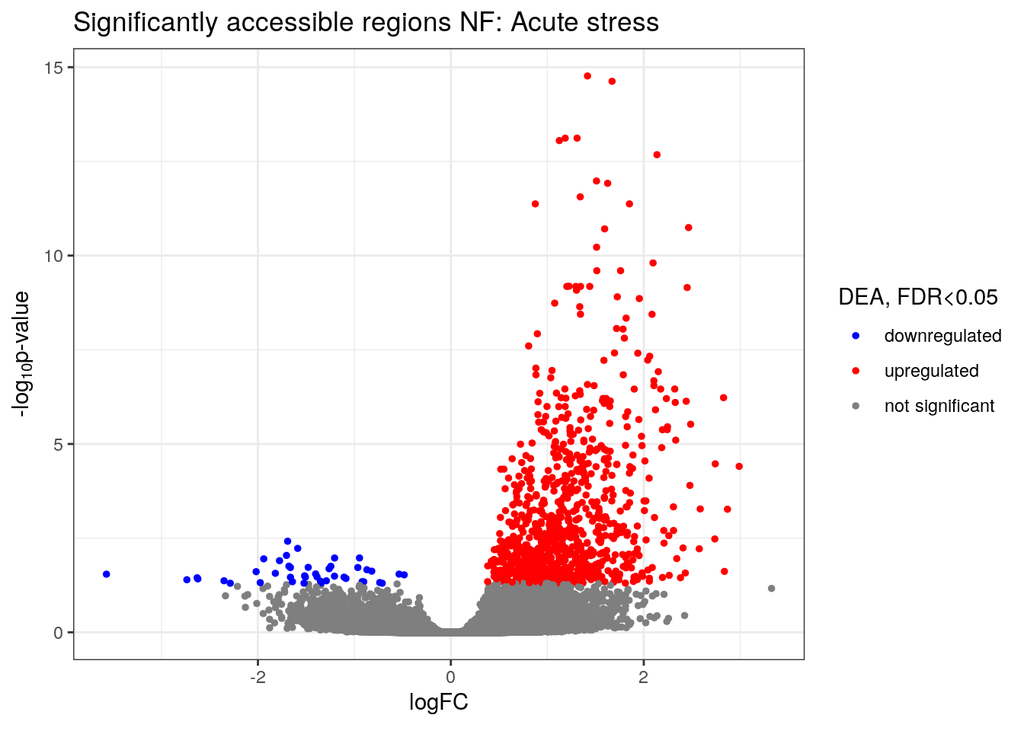

FIGURE 6: Volcanoplot showing significantly accessible nucleosome-free regions between control and acutely-stressed animals

```r
#classify sign. up and downregulated peaks
results_M_NF$Marrocco.acute$table$diff[results_M_NF$Marrocco.acute$table$FDR < 0.05 & results_M_NF$Marrocco.acute$table$logFC >0] <- "UP"
results_M_NF$Marrocco.acute$table$diff[results_M_NF$Marrocco.acute$table$FDR < 0.05 & results_M_NF$Marrocco.acute$table$logFC <0] <- "DOWN"

#visualize results
ggplot(results_M_NF$Marrocco.acute$table, aes(logFC, -log10(FDR), col=results_M_NF$Marrocco.acute$table$diff)) + geom_point(size=1) + theme_bw() + scale_color_manual(values = c("blue", "red"), labels =c ("downregulated", "upregulated", "not significant")) + ggtitle('Significantly accessible regions NF: Acute stress') + labs(color = 'DEA, FDR<0.05', x = expression("logFC"), y = expression("-log"[10]*"p-value"))
```

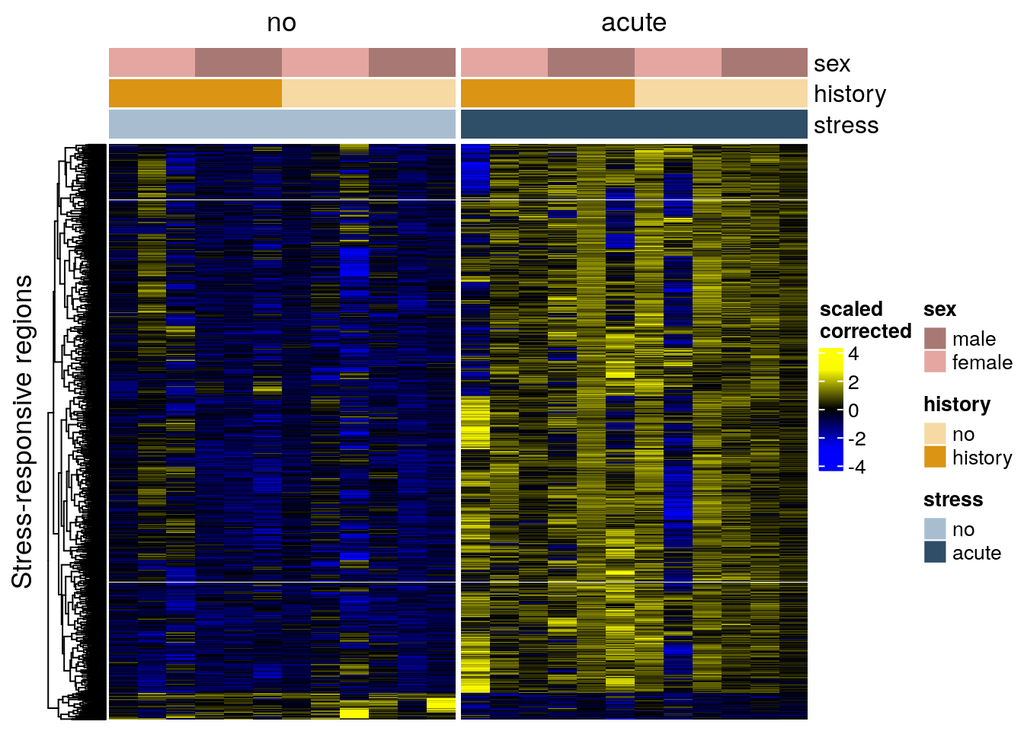

FIGURE 7: Heatmap showing differentially-accessible nucleosome-free regions between control and acutely-stressed animals (corrected)

```r
#add metadata column to SE object to define colors
metadata(se_NF)$anno_colors$stress <- c(no="#A8BED0", acute="#2F4E67")
metadata(se_NF)$anno_colors$history <- c(no="#F7D9A3", history="#DB9413")
metadata(se_NF)$anno_colors$sex <- c(male="#A87974", female="#E4A6A0")

#visualize uncorrected counts in heatmap
#sechm(se_NF,features = rownames(topTags(results_M_NF$Marrocco.acute, n = Inf, p.value = 0.05)), do.scale=TRUE, assayName="counts", row_title="Stress-responsive regions", gaps_at = "stress", cluster_rows = TRUE, top_annotation=c("sex", "history", "stress"))

#visualize corrected counts in heatmap
sechm(se_NF,features = rownames(topTags(results_M_NF$Marrocco.acute, n = Inf, p.value = 0.05)), do.scale=TRUE, assayName="corrected", row_title="Stress-responsive regions", gaps_at = "stress", cluster_rows = TRUE, top_annotation=c("sex", "history", "stress"))
```

```r
#save summarized experiments object
saveRDS(se_NF, file="MarroccopeaksNF.SE.rds")
```

911 regions are differentially accessible between acutely stressed (FSS, double-hit) and non-acutely stressed (Control, ARS) animals using only nucleosome-free reads, correcting for the different history of stress, sex and covariate. Again, most of the sign. altered regions (868 regions) show increased accessibility in response to stress (Fig. 6 & 7). History of stress explains only very few sign. different regions (10), which will not be further evaluated here.

```r
#subset all significant stress peaks
#dim(results_M[["Marrocco.acute"]]$table) #99852
#length(merged_peaksM) #99852
peaksM_NF_stress_sig <- merged_peaksM_NF[which(results_M_NF[["Marrocco.acute"]]$table$FDR<0.05)]
#length(peaksM_NF_stress_sig) #911 peaks

#subset sign. upregulated peaks
peaksM_NF_stress_sigup <- merged_peaksM_NF[which((results_M_NF[["Marrocco.acute"]]$table$FDR<0.05) & (results_M_NF[["Marrocco.acute"]]$table$logFC>0))]
#length(peaksM_NF_stress_sigup) #868

#subset sign. downregulated peaks
peaksM_NF_stress_sigdown <- merged_peaksM_NF[which((results_M_NF[["Marrocco.acute"]]$table$FDR<0.05) & (results_M_NF[["Marrocco.acute"]]$table$logFC<0))]
#length(peaksM_NF_stress_sigdown) #43

#save peaks
saveRDS(peaksM_NF_stress_sig, file="peaksM_NF_stress_sig.rds")
saveRDS(peaksM_NF_stress_sigup, file="peaksM_NF_stress_sigup.rds")
saveRDS(peaksM_NF_stress_sigdown, file="peaksM_NF_stress_sigdown.rds")
saveRDS(merged_peaksM_NF, file="merged_peaksM_NF.rds")
```

## Enrichment analysis of stress-upregulated peaks

Enrichment analysis on the NF-peaks was performed using the rGREAT server. As background, all accessible peaks (merged NF peaks file that was previously used to construct the SE object) from the Marrocco dataset will be used.

```r
#perform enrichment analysis using rGREAT server
library(rGREAT)

#adjust seqlevelStyle for rGREAT server
seqlevelsStyle(merged_peaksM_NF) <- "UCSC"
seqlevelsStyle(peaksM_NF_stress_sig) <- "UCSC"
seqlevelsStyle(peaksM_NF_stress_sigup) <- "UCSC"
seqlevelsStyle(peaksM_NF_stress_sigdown) <- "UCSC"

#only keep common chromosome names and clean up Granges for rGREAT
seqnames(merged_peaksM_NF)
```

```
## factor-Rle of length 141235 with 29 runs
##   Lengths:       9722       7061       9549 ...       2561         14
##   Values : chr1       chr10      chr11      ... chrX       chrY
## Levels(49): chr1 chr10 chr11 chr12 ... GL456383.1 GL456212.1 GL456221.1
```

```r
chrom <- c("chr1", "chr10", "chr11", "chr12", "chr13", "chr14", "chr15", "chr16", "chr17", "chr18", "chr19", "chr2", "chr3", "chr4", "chr5", "chr6", "chr7", "chr8", "chr9", "chrM", "chrX", "chrY")
merged_peaksM_NF_chrom<- keepSeqlevels(merged_peaksM_NF, value=chrom, pruning.mode="coarse")
length(merged_peaksM_NF_chrom) #141203
```

```
## [1] 141203
```

```r
names(merged_peaksM_NF_chrom) <-NULL
seqnames(peaksM_NF_stress_sig)
```

```
## factor-Rle of length 911 with 20 runs
##   Lengths:    65    46    59    35    41 ...    56    58    52    52     9
##   Values : chr1  chr10 chr11 chr12 chr13 ... chr6  chr7  chr8  chr9  chrX
## Levels(49): chr1 chr10 chr11 chr12 ... GL456383.1 GL456212.1 GL456221.1
```

```r
peaksM_NF_stress_sig_chrom<- keepSeqlevels(peaksM_NF_stress_sig, value=chrom, pruning.mode="coarse")
length(peaksM_NF_stress_sig_chrom) #911
```

```
## [1] 911
```

```r
names(peaksM_NF_stress_sig_chrom) <-NULL
peaksM_NF_stress_sigup_chrom<- keepSeqlevels(peaksM_NF_stress_sigup, value=chrom, pruning.mode="coarse")
length(peaksM_NF_stress_sigup_chrom) #868
```

```
## [1] 868
```

```r
names(peaksM_NF_stress_sigup_chrom) <-NULL
peaksM_NF_stress_sigdown_chrom<- keepSeqlevels(peaksM_NF_stress_sigdown, value=chrom, pruning.mode="coarse")
length(peaksM_NF_stress_sigdown_chrom) #43
```

```
## [1] 43
```

```r
names(peaksM_NF_stress_sigdown_chrom) <-NULL

#get enrichment results for all sign peaks
#job_stressNF_sig <- rGREAT::submitGreatJob(gr=peaksM_NF_stress_sig_chrom, bg=merged_peaksM_NF_chrom, species="mm10") #we use mm10, cause GRCm38 is not supported
#res_stressNF_sig <- rGREAT::getEnrichmentTables(job_stressNF_sig)
#res_stressNF_sig

#plot the top 30 Biological processes
#bp_stressNF_sig <- res_stressNF_sig$`GO Biological Process`
#bp_stressNF_sig
#sum(bp_stressNF_sig$Hyper_Adjp_BH<0.05) #49 GO terms are sign. enriched
#ggplot(head(bp_stressNF_sig,30), aes(Hyper_Fold_Enrichment, reorder(name, Hyper_Adjp_BH), size=Hyper_Foreground_Region_Hits, color=-log10(Hyper_Adjp_BH))) + geom_point() + scale_color_viridis_c() + ggtitle("Stress-responsive peaks: Biological Processes") + scale_y_discrete(labels = label_wrap(50))

#get enrichment results for all sign upregulated peaks
job_stressNF_sigup <- rGREAT::submitGreatJob(gr=peaksM_NF_stress_sigup_chrom, bg=merged_peaksM_NF_chrom, species="mm10") #we use mm10, cause GRCm38 is not supported
res_stressNF_sigup <- rGREAT::getEnrichmentTables(job_stressNF_sigup)
```

```
## The default enrichment tables contain no associated genes for the input
## regions. You can set `download_by = 'tsv'` to download the complete
## table, but note only the top 500 regions can be retreived. See the
## following link:
##
## https://great-help.atlassian.net/wiki/spaces/GREAT/pages/655401/Export#Export-GlobalExport
```

```r
#res_stressNF_sigup

#plot the top 30 Biological processes
bp_stressNF_sigup <- res_stressNF_sigup$`GO Biological Process`
#bp_stressNF_sig
sum(bp_stressNF_sigup$Hyper_Adjp_BH<0.05) #52 GO terms are sign. enriched
```

```
## [1] 56
```

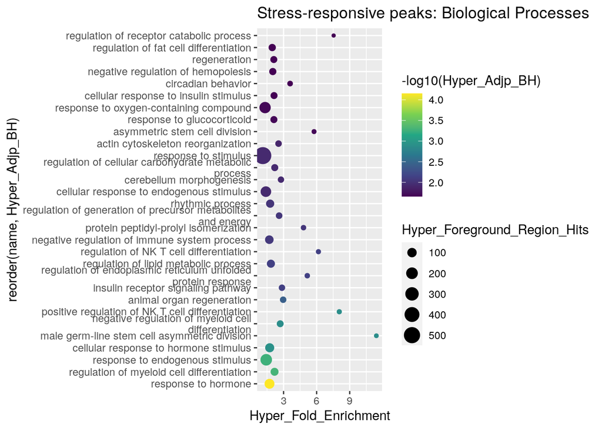

FIGURE 8: Enrichment analysis of significantly more accessible nucleosome-free regions

```r
ggplot(head(bp_stressNF_sigup,30), aes(Hyper_Fold_Enrichment, reorder(name, Hyper_Adjp_BH), size=Hyper_Foreground_Region_Hits, color=-log10(Hyper_Adjp_BH))) + geom_point() + scale_color_viridis_c() + ggtitle("Stress-responsive peaks: Biological Processes") + scale_y_discrete(labels = label_wrap(50))
```

```r
#get enrichment results for all sign downregulated peaks
job_stressNF_sigdown <- rGREAT::submitGreatJob(gr=peaksM_NF_stress_sigdown_chrom, bg=merged_peaksM_NF_chrom, species="mm10") #we use mm10, cause GRCm38 is not supported
```

```
## Don't make too frequent requests. The time break is 60s.
## Please wait for 45s for the next request.
## The time break can be set by `request_interval` argument.
```

```r
res_stressNF_sigdown <- rGREAT::getEnrichmentTables(job_stressNF_sigdown)
```

```
## The default enrichment tables contain no associated genes for the input
## regions. You can set `download_by = 'tsv'` to download the complete
## table, but note only the top 500 regions can be retreived. See the
## following link:
##
## https://great-help.atlassian.net/wiki/spaces/GREAT/pages/655401/Export#Export-GlobalExport
```

```r
#res_stressNF_sigdown

#plot the top 20 Biological processes
bp_stressNF_sigdown <- res_stressNF_sigdown$`GO Biological Process`
#bp_stressNF_sigdown
sum(bp_stressNF_sigdown$Hyper_Adjp_BH<0.05) #0 GO terms are sign. enriched
```

```
## [1] 0
```

Performing enrichment analysis on all sign. different more accessible regions between acutely stressed and control animals in the Marrocco dataset using only NF reads, reveals the same enrichment of response to glucocorticoids (Fig. 8). This is consistently observed when testing all sign. altered regions. Sign. downregulated regions however, do not yield any significant enrichment.

## Compare peaks

Next, we compare the sign. altered peaks between all accessible regions and accessible regions from the nucleosome-free reads only, defined by the previous differential analysis.

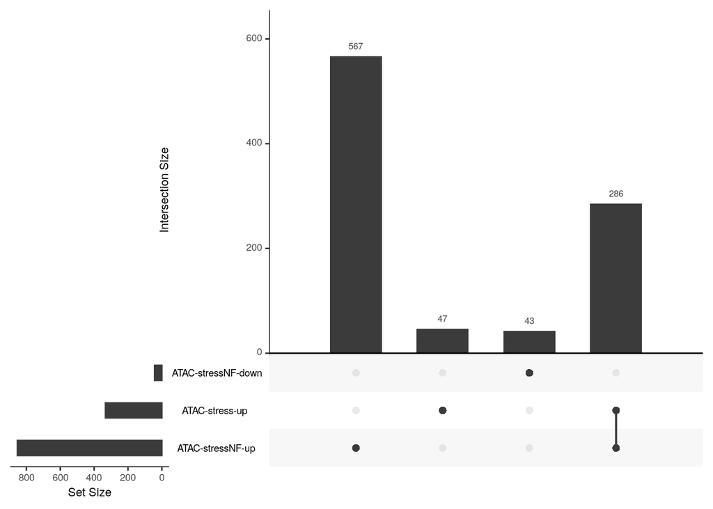

FIGURE 9: Upset plot showing overlaps of peaks between the regions with significantly altered regions

```r
#prepare list of peaks
peaksMarrocco_sig<- GRangesList("ATAC-stress-up" = peaksM_stress_sigup_chrom, "ATAC-stressNF-down" = peaksM_NF_stress_sigdown_chrom, "ATAC-stressNF-up" = peaksM_NF_stress_sigup_chrom)
#peaksMarrocco_sig
regionUpset(peaksMarrocco_sig)
```

```r
#calculate fraction of shared peaks between the upregulated peaks
sum(overlapsAny(peaksM_stress_sigup_chrom, peaksM_NF_stress_sigup_chrom)) #286
```

```
## [1] 286
```

Most of the sign. altered upregulated regions of all accessible regions overlap with sign. more accessible peaks of nucleosome-free regions (Fig. 9).

Given the further focus on GR, which is a TF, the nucleosome-free peaks and the corresponding significant peaks will be used for all further analyses.